# Basic descriptive statistics made easy with Python libraries

# Part 6 - Hypothesis Testing

## Case 1 - One-sample t-test

ศึกษาความแตกต่างของค่าที่มาจากกลุ่มตัวอย่างว่าต่างจากค่าคาดหมายแค่ไหน ตามสูตร ในกรณีนี้ เราจะศึกษาว่าคะแนนของนักเรียนในห้อง 501-503 วิชาโครงงาน (score) มีความแตกต่างจากคะแนนที่ครูอยากให้ได้ (expected_score) อย่างมีนัยสำคัญหรือไม่

```python
# ให้คะแนนเฉลี่ยที่ 90.5 คะแนน และมี sd=3
score = getdata(N = 100, mean = 90.5, stdev = 3, MIN = 0, MAX =100)
expected_score = 90
ttest = stats.ttest_1samp(score, expected_score)
pvalue = ttest[1]
if ttest[0]>0:
    ishigher = 'lower'
else:
    ishigher = 'higher'
print(f'pvalue = {round(pvalue,2)}, which is significantly {ishigher} at a confidence value of {round((1-pvalue)*100,2)} percent')
```

[output not shown]

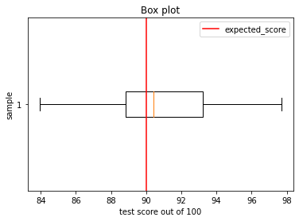

```python
plt.boxplot([score], vert=False)
plt.title('Box plot')
plt.xlabel('test score out of 100')
plt.ylabel('sample')
plt.axvline(x=expected_score, c='red', label='expected_score')
plt.legend()
plt.show()
```

## Case 2 - Paired T-Test

ศึกษาความแตกต่างของค่าสองค่าที่วัดจากกลุ่มตัวอย่าง 1 กลุ่ม โดยค่าหนึ่งเป็นผลกระทบของอีกค่า ตามสูตร ในกรณีนี้ เราจะศึกษาว่าคะแนนของนักเรียนในห้อง 501-503 วิชาโครงงาน ก่อนครูสอน (pre_test) และหลัง (post_test) ต่างกันอย่างมีนัยสำคัญหรือไม่

```python
pre_test = getdata(N = 100, mean = 90, stdev = 3.5, MIN = 0, MAX =100)
post_test = getdata(N = 100, mean = 90.3, stdev = 3.2, MIN = 0, MAX =100)
ttest = stats.ttest_rel(pre_test, post_test)
pvalue = ttest[1]
if ttest[0]>0:
    ishigher = 'lower'
else:
    ishigher = 'higher'
print(f'pvalue = {round(pvalue,2)}, which means post test is significantly {ishigher} at a confidence value of {round((1-pvalue)*100,2)} percent')
```

```
pvalue = 0.02, which means post test is significantly higher at a confidence value of 98.25 percent
```

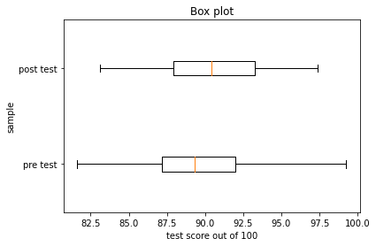

```python
plt.boxplot([pre_test, post_test], vert=False, labels=['pre test', 'post test'])
plt.title('Box plot')
plt.xlabel('test score out of 100')
plt.ylabel('sample')
plt.show()
```

## Case 3 - Independent T-Test

ศึกษาความแตกต่างของค่าสองค่าไม่เกี่ยวกัน จากกลุ่มตัวอย่างเดียวกัน ตามสูตร

[figure not shown]

ในกรณีนี้ เราจะศึกษาว่า ครูเคมีหรือครูชีวะ ให้คะแนนคะแนนของนักเรียนในห้อง 501-503 วิชาโครงงานยากกว่ากันอย่างมีนัยสำคัญหรือไม่

```python
chem_score = getdata(N = 100, mean = 90, stdev = 3.5, MIN = 0, MAX =100)
bio_score = getdata(N = 100, mean = 91, stdev = 3.2, MIN = 0, MAX =100)
ttest = stats.ttest_ind(chem_score, bio_score)
pvalue = ttest[1]
if ttest[0]>0:
    ishigher = 'lower'
else:
    ishigher = 'higher'
print(f'pvalue = {round(pvalue,2)}, which means biology test score is significantly {ishigher} at a confidence value of {round((1-pvalue)*100,2)} percent')
```

```
pvalue = 0.02, which means biology test score is significantly higher at a confidence value of 97.68 percent
```

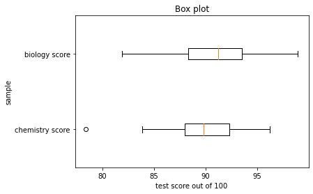

```python
plt.boxplot([chem_score, bio_score], vert=False, labels=['chemistry score', 'biology score'])
plt.title('Box plot')
plt.xlabel('test score out of 100')
plt.ylabel('sample')
plt.show()
```

## Case 4 - One Way Analysis of Variance (ANOVA)

ศึกษาความแตกต่างของค่าจากหลายๆ กลุ่มตัวอย่าง หรือค่ามากกว่าหรือเท่ากับ 2 ค่าจากกลุ่มตัวอย่างเดียวกัน ว่าแตกต่างกันนัยสำคัญหรือไม่ สูตรค่อนข้างซับซ้อนจึงไม่ได้ใส่ไว้

เราจะศึกษาว่า คะแนนวิชาเลข ฟิสิกส์ เคมี ชีวะ มีวิชาไหนที่ต่างจากวิชาอื่นอย่างนัยสำคัญไหม

```python
chem_score = getdata(N = 100, mean = 90, stdev = 3.5, MIN = 0, MAX =100)
bio_score = getdata(N = 100, mean = 91, stdev = 3.2, MIN = 0, MAX =100)
math_score = getdata(N = 100, mean = 92, stdev = 3.4, MIN = 0, MAX =100)
phys_score = getdata(N = 100, mean = 91.5, stdev = 3.0, MIN = 0, MAX =100)

anova = stats.f_oneway(chem_score, bio_score, math_score, phys_score)
print(f'pvalue = {round(pvalue,2)}, which means the scores are different at a confidence value of {round((1-pvalue)*100,2)} percent')
```

[output not shown]

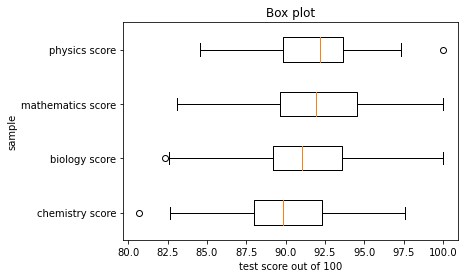

```python
plt.boxplot([chem_score, bio_score, math_score, phys_score], vert=False, labels=['chemistry score', 'biology score', 'mathematics score', 'physics score'])
plt.title('Box plot')
plt.xlabel('test score out of 100')
plt.ylabel('sample')
plt.show()
```